## Exploratory Data Analysis Of `c_m_TRANSFORMED.csv`

**This EDA section is a reevaluation square root transformed, `c_m_RAW_ACC.csv` data set, hence called `c_m_TRANSFORMED.csv`.**

The $\sqrt x_i$ *Transformed* data was derived from `c_m_RAW_ACC.csv` where the amino acids C, F, I were transformed using a square root function. This transformation was done in order to reduce the skewness of these samples and avoid modeling problems arising from high skewness, as seen below.

| Amino Acid | Initial skewness | Skew after square root transformation |
| --- | --- | --- |
| C, Cysteine | 2.538162 | 0.3478132 |
| F, Phenolalanine | 2.128118 | -0.102739 |
| I, Isoleucine | 2.192145 | 0.2934749 |

### Import Transformed data

```r
c_m_TRANSFORMED <- read_csv("../00-data/02-aac_dpc_values/c_m_TRANSFORMED.csv")
Class <- as.factor(c_m_TRANSFORMED$Class)
```

### Check Transformed dataframe dimensions

```r
dim(c_m_TRANSFORMED)
```

```
## [1] 2340   23
```

### Check Transformed for missing values

```r
apply(is.na(c_m_TRANSFORMED), 2, which)
```

```
## integer(0)
```

- **No missing values found.**

### Count Transformed data for number of polypeptides per class

Number of polypeptides per Class:

- Class 0 = Control,
- Class 1 = Myoglobin

```
##
##    0    1
## 1216 1124
```

## Visualization of Transformed Data Descriptive Statistics

Formulas for mean:
$$E[X] = \sum_{i=1}^n x_i p_i ~~; ~~~~~~ \bar x = \frac {1}{n} \sum_{i=1}^n x_i$$

### Scatter plot of means of *Myoglobin-Control* amino acid composition $\sqrt x_i$ Transformed (c_m_TRANSFORMED) dataframe

- This plot shows the means for each feature (column-means) in the dataset. The means represent the ungrouped or total of all proteins (where n=2340) versus AA type.

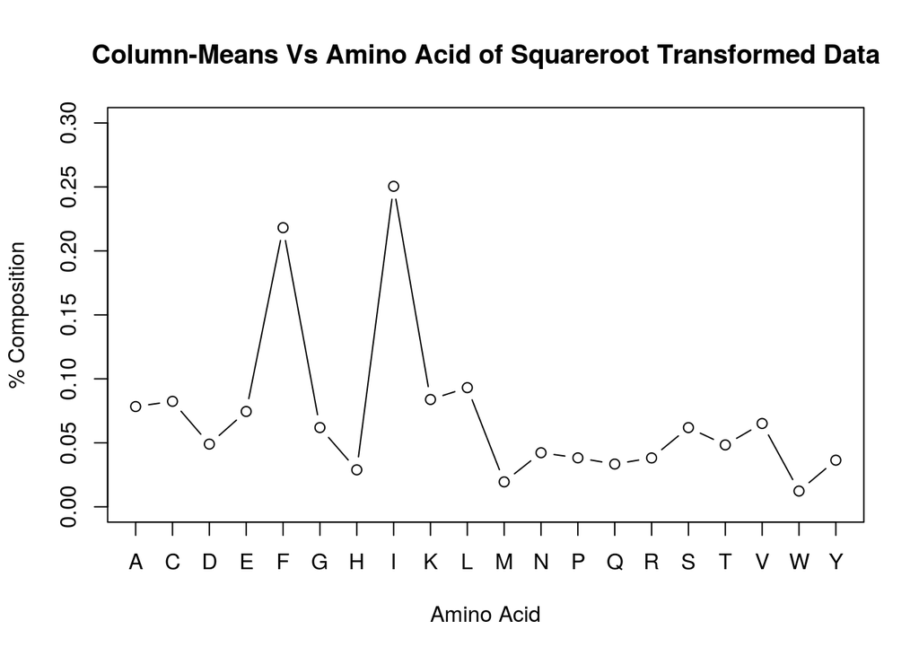

### Grouped barchart of means for percent amino acid composition of Transformed Data; control & myoglobin categories

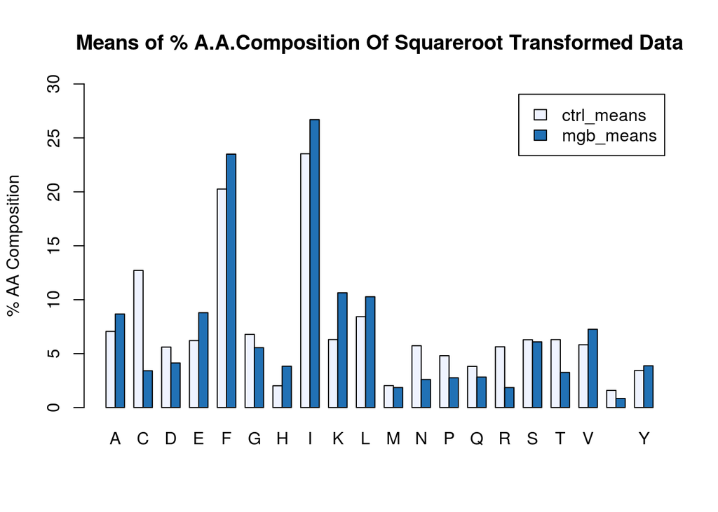

### Boxplots of grand-means of overall amino acid composition of squareroot transformed data

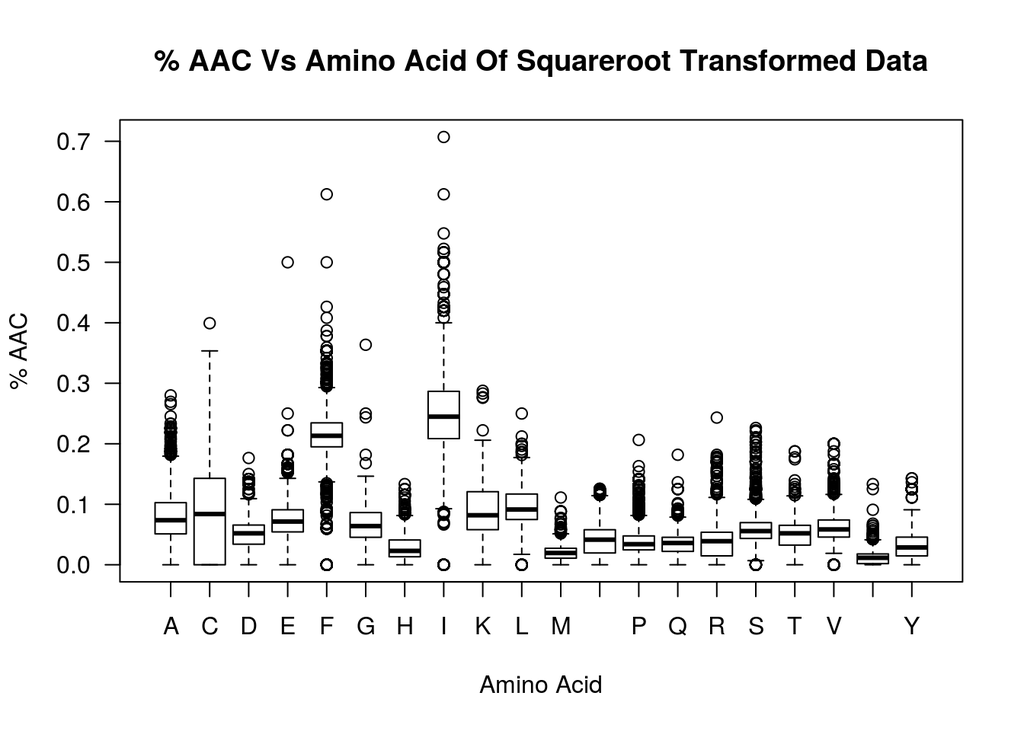

### Boxplots of amino acid compositions for control (only) of squareroot transformed data

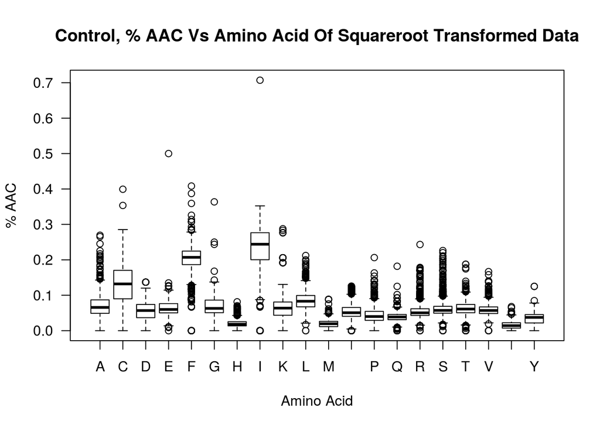

### Boxplots of amino acid compositions for myoglobin of squareroot transformed Data(only) of squareroot transformed data

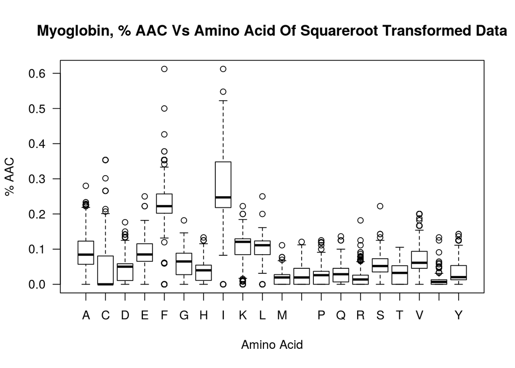

### Boxplots Of Length Of Polypeptides Of Transformed Data; Myoglobin, Control & Combined

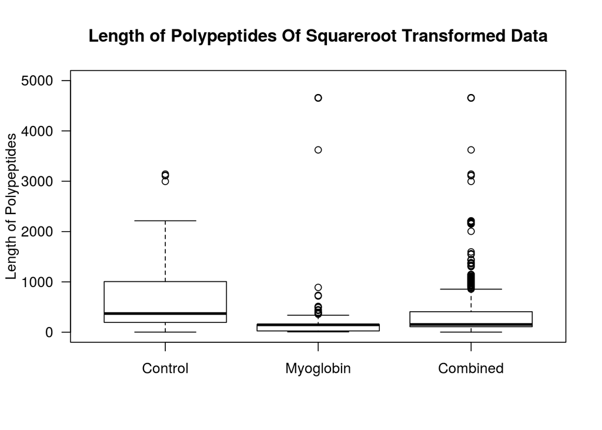

### Coefficient of variance (CV) Of Transformed data

Standard deviations are sensitive to scale. Therefore I compare the normalized standard deviations. This normalized standard deviation is more commonly called coefficient of variation (CV).

$$CV = \frac {\sigma (x)} {E [|x|]} ~~~ where ~~~ \sigma(x) \equiv \sqrt{ E[x - \mu]^2 }$$

$$CV ~~=~~ \frac{1}{\bar x} \cdot \sqrt{ \frac{1}{n-1} \sum^n_{i=1} (x_i - \bar x)^2}$$

### Plot of normalized standard deviations

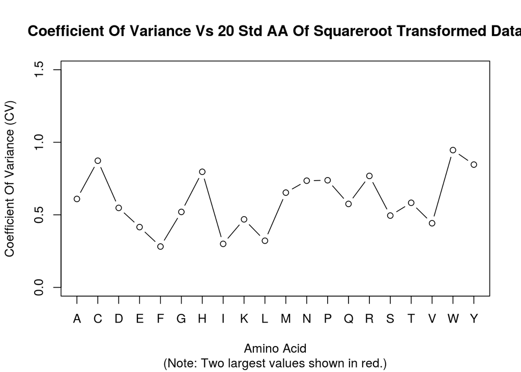

```r
AA_var_norm
```

```
##         A         C         D         E         F         G         H         I
## 0.6095112 0.8729758 0.5478540 0.4156102 0.2815745 0.5201625 0.7966296 0.2999687
##         K         L         M         N         P         Q         R         S
## 0.4689544 0.3215591 0.6529752 0.7352478 0.7383244 0.5752622 0.7680977 0.4948690
##         T         V         W         Y
## 0.5830352 0.4420595 0.9461276 0.8461615
```

### Skewness of distributions Of Transformed Data

$$Skewness ~= E\left[ \left( \frac{X - \mu}{\sigma(x)} \right)^3 \right] ~~~~ where ~~~~ \sigma(x) \equiv \sqrt{ E[x - \mu]^2 }$$

$$Skewness ~= \frac { \frac{1}{n} \sum^n_{i=1} (x_i - \bar x)^3 } { \left( \sqrt{ \frac{1}{n-1} \sum^n_{i=1} (x_i - \bar x)^2 } \right) ^ {3}}$$

- Skewness values for each A.A. by Class of squareroot transformed data

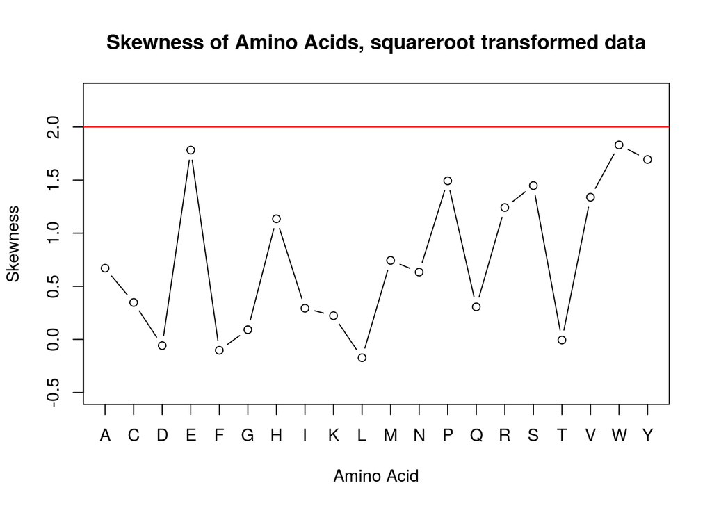

```r
AA_skewness
```

```
##            A            C            D            E            F            G
##  0.670502595  0.347813248 -0.058540442  1.782876260 -0.102739748  0.091338300
##            H            I            K            L            M            N
##  1.135783661  0.293474879  0.223433207 -0.172566877  0.744002991  0.633532783
##            P            Q            R            S            T            V
##  1.493903282  0.306716333  1.241930812  1.448521897 -0.006075043  1.338971930
##            W            Y
##  1.831047440  1.694362388
```

### QQ Plots of 20 amino acids of Transformed data

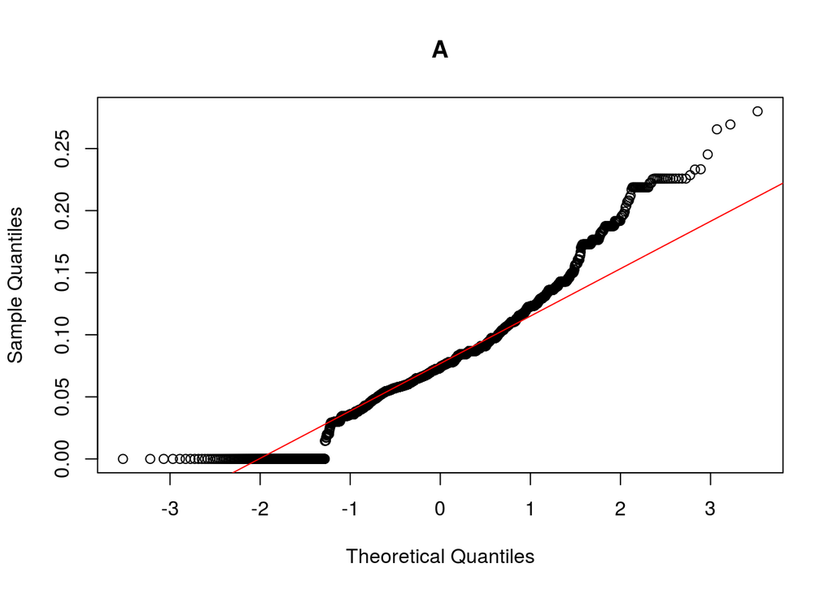

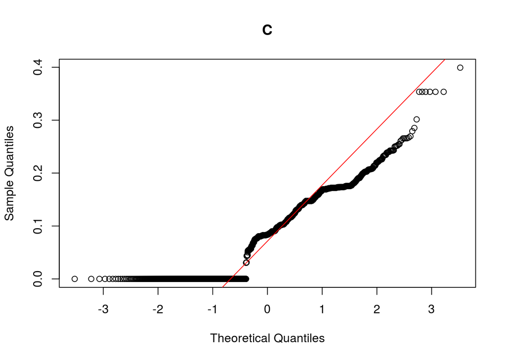

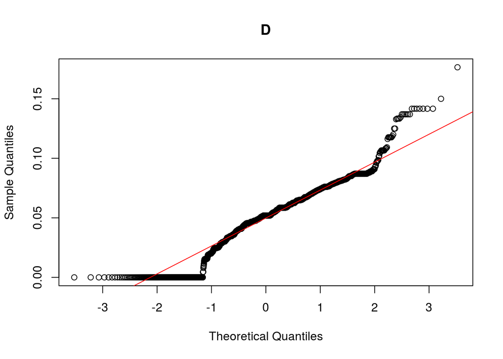

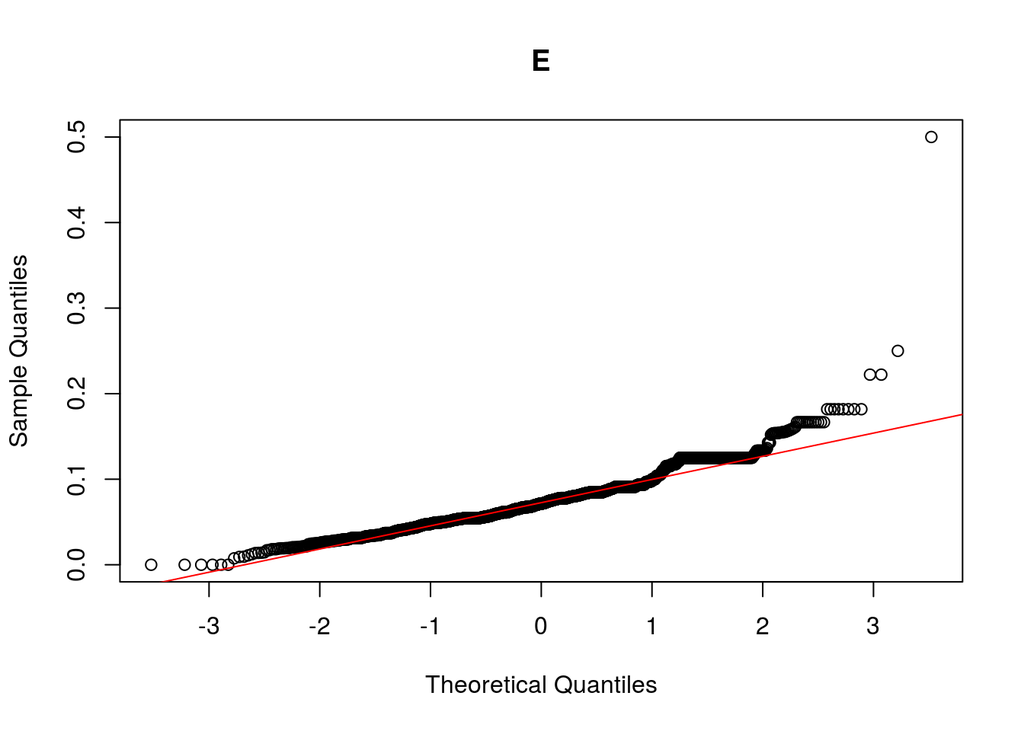

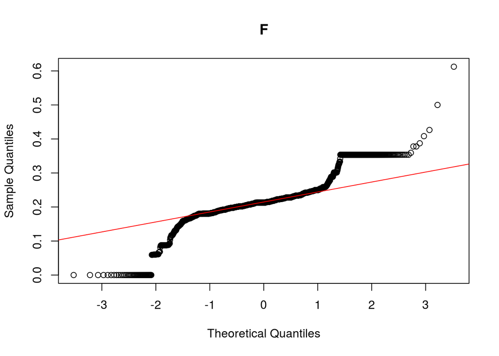

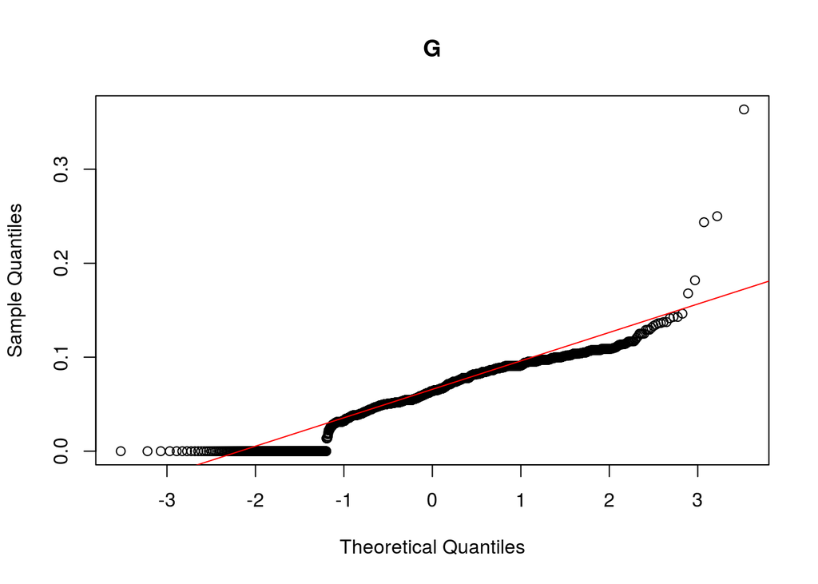

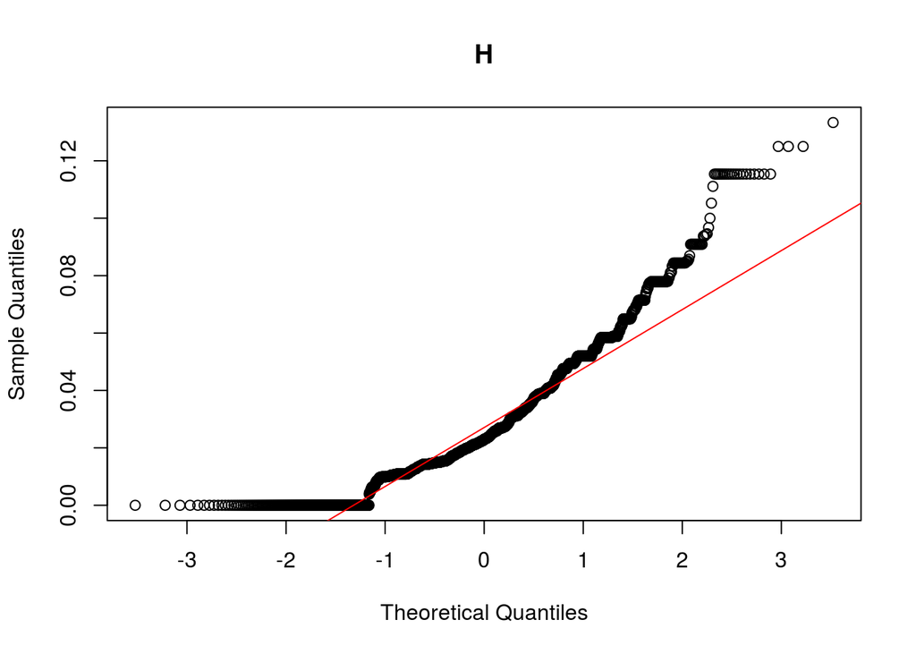

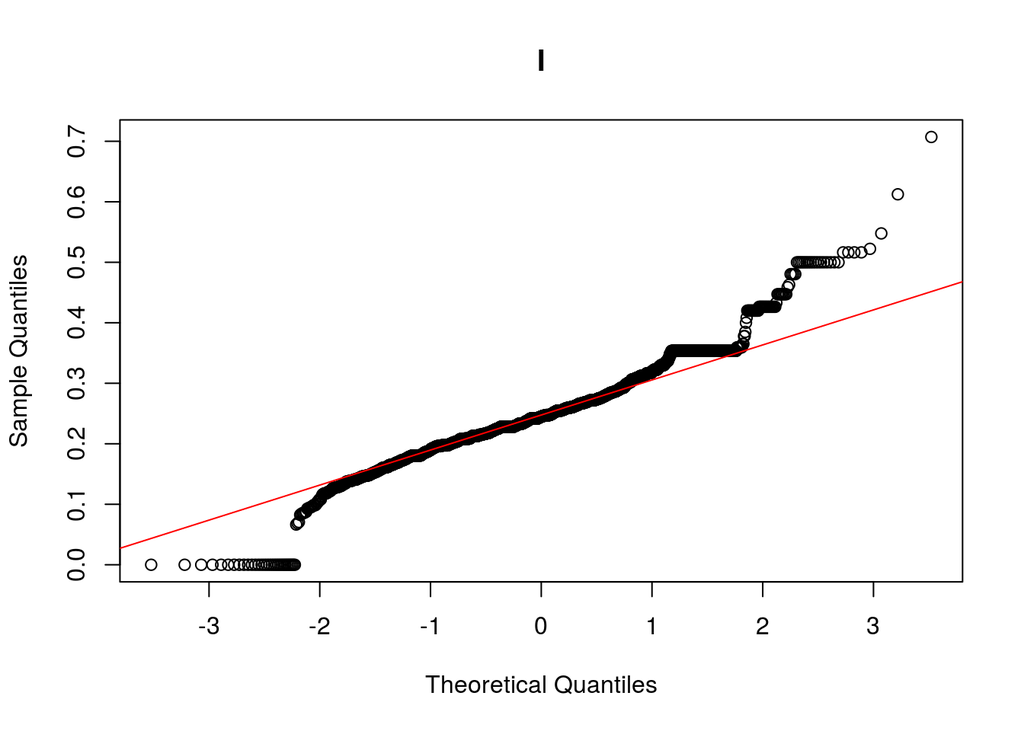

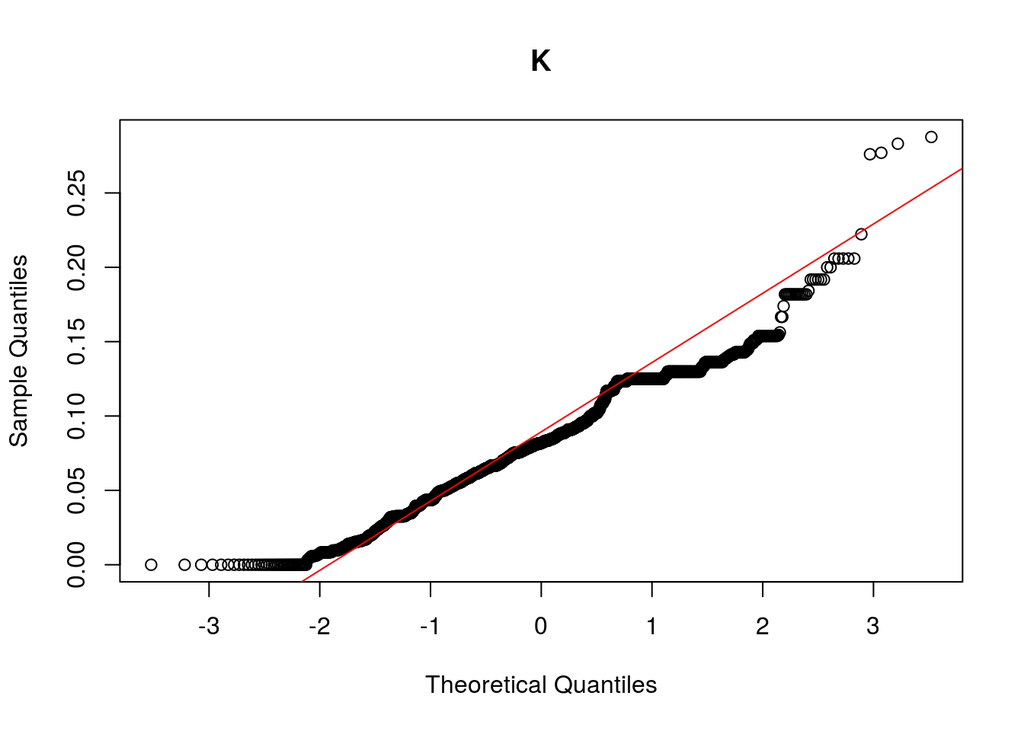

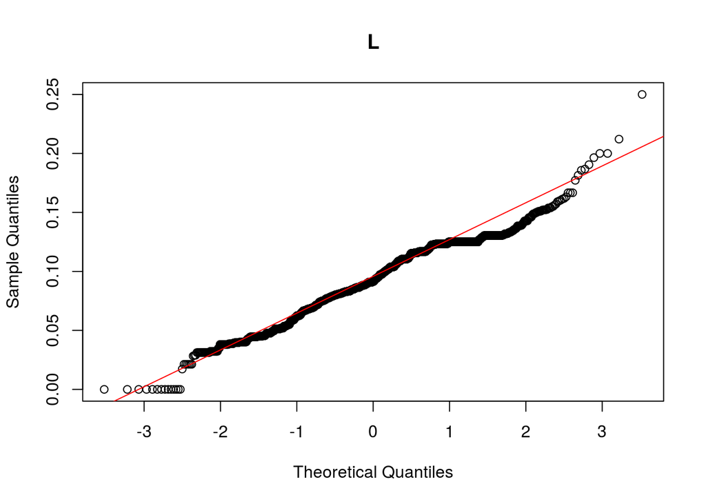

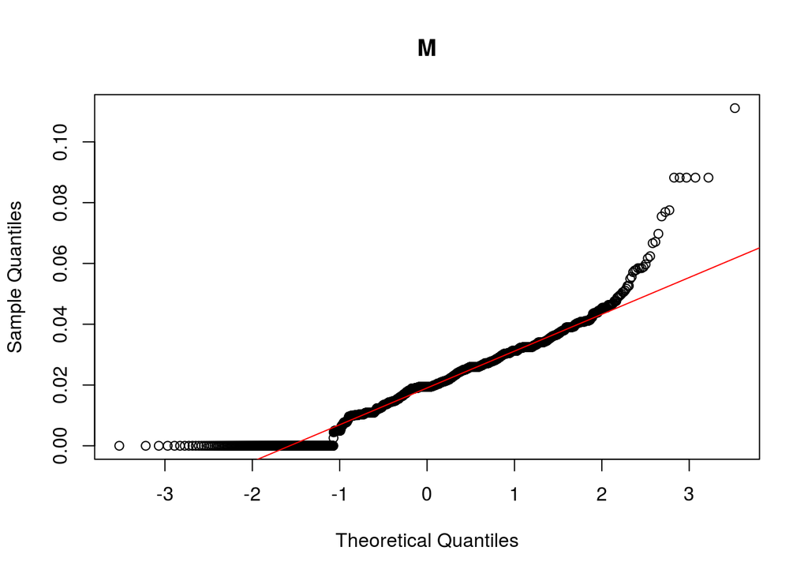

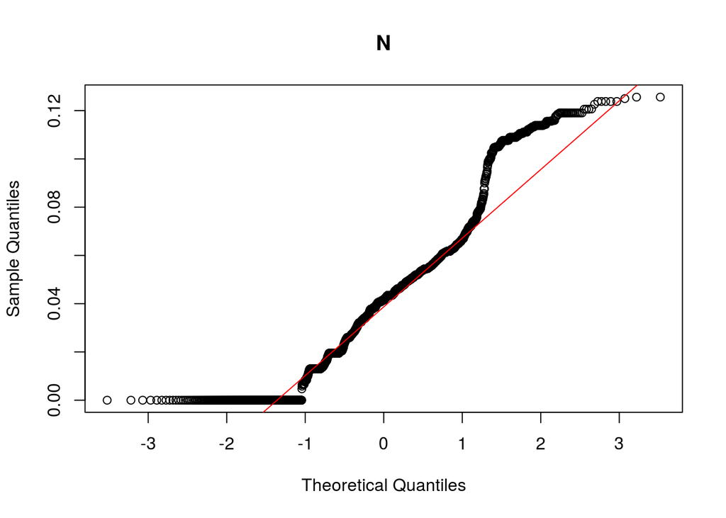

[8 more figures not shown]

### Determine coefficients of correlation of Transformed Data

An easily interpretable test, is correlation 2D-plot for investigating multicollinearity or feature reduction. It is clear that fewer attributes “means decreased computational time and complexity. Secondly, if two predictors are highly correlated, this implies that they are measuring the same underlying information. Removing one should not compromise the performance of the model and might lead to a more parsimonious and interpretable model. Third, some models can be crippled by predictors with degenerate distributions”.[^1]

Pearson’s correlation coefficient:
$$\rho_{x,y} = \frac {E \left[(X - \mu_x)(X - \mu_y) \right]} {\sigma_x \sigma_y}$$

$$r_{xy} = \frac {\sum^n_{i=1} (x_i - \bar x)(y_1 - \bar y)} { {\sqrt {\sum^n_{i=1} (x_i - \bar x)^2 }} {\sqrt {\sum^n_{i=1} (y_i - \bar y)^2 }} }$$

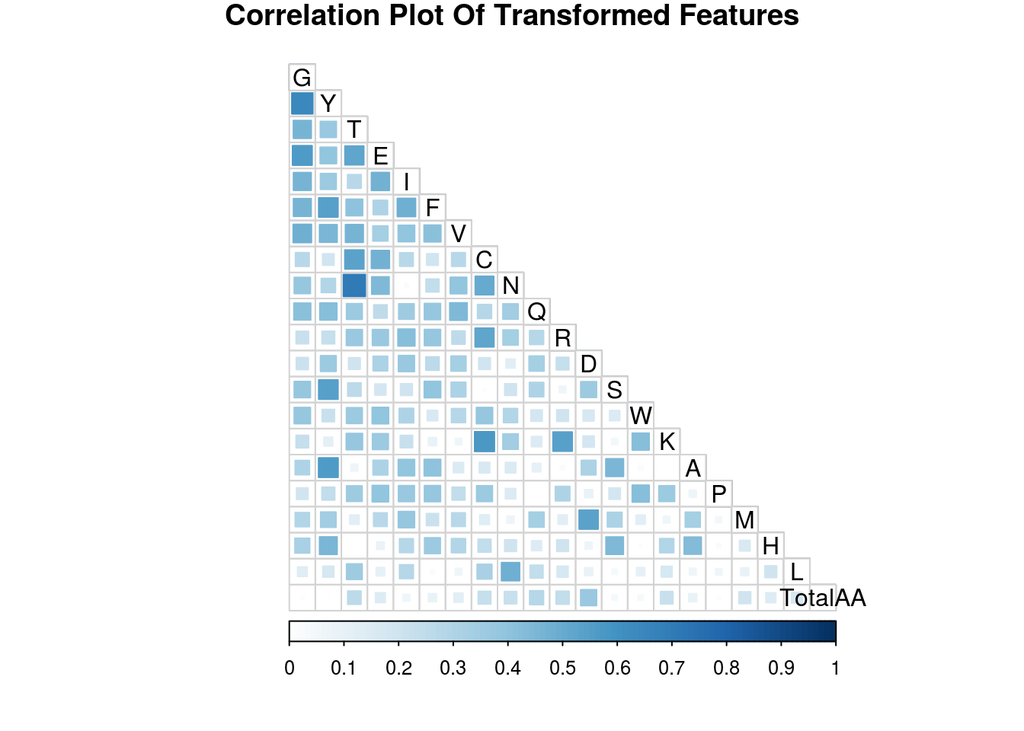

```r
c_m_corr_mat["T", "N"]
```

```
## [1] 0.7098085
```

```r
c_m_corr_mat["Y", "A"]
```

```
## [1] -0.5602272
```

### Boruta - dimensionality reduction of Transformed data

**Perform Boruta search**

NOTE: *mcAdj = TRUE*: If True, multiple comparisons will be adjusted using the Bonferroni method to calculate p-values. Therefore, $p_i \leq \frac {\alpha} {m}$ where $\alpha$ is the desired p-value and $m$ is the total number of null hypotheses.

```r
set.seed(1000)
registerDoMC(cores = 3)  # Start multi-processor mode
start_time <- Sys.time() # Start timer

boruta_output <- Boruta(Class ~ .,
                        data = c_m_class_20[,-1],
                        mcAdj = TRUE, # See Note above.
                        doTrace = 1) # doTrace = 1, represents non-verbose mode.

registerDoSEQ()  # Stop multi-processor mode
end_time <- Sys.time()   # End timer
end_time - start_time    # Display elapsed time
```

```
## Time difference of 17.08479 secs
```

**Plot variable importance**

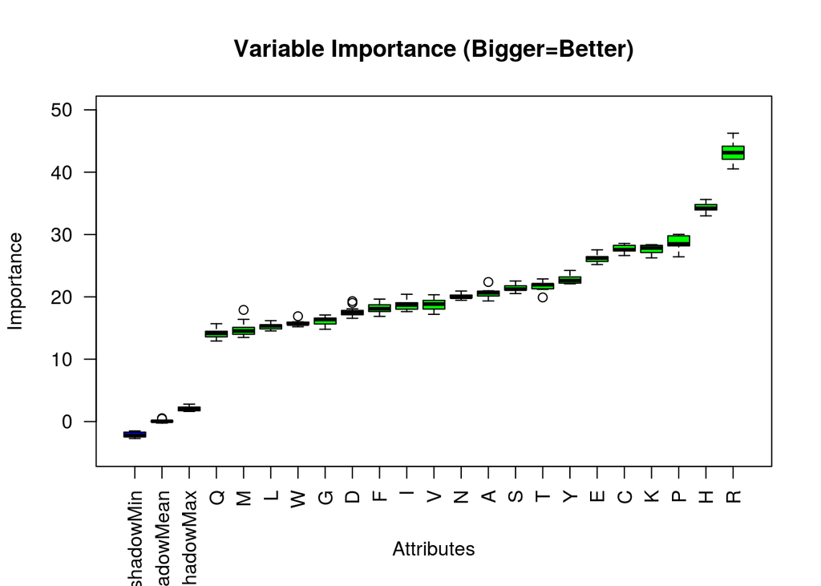

```r
plot(boruta_output,
     cex.axis = 1,
     las = 2,
     ylim = c(-5,50),
     main = "Variable Importance (Bigger=Better)")
```

**Variable importance scores**

```r
roughFixMod <- TentativeRoughFix(boruta_output)
imps <- attStats(roughFixMod)
imps2 <- imps[imps$decision != "Rejected", c("meanImp", "decision")]
meanImps <- imps2[order(-imps2$meanImp), ]  # descending sort

knitr::kable(meanImps,
             full_width = F,
             position = "left",
             caption  = "Mean Importance Scores & Decision")
```

Mean Importance Scores & Decision

|  | meanImp | decision |
| --- | --- | --- |
| R | 43.17613 | Confirmed |
| H | 34.30370 | Confirmed |
| P | 28.70674 | Confirmed |
| C | 27.72357 | Confirmed |
| K | 27.60838 | Confirmed |
| E | 26.18872 | Confirmed |
| Y | 22.84975 | Confirmed |
| T | 21.66359 | Confirmed |
| S | 21.44119 | Confirmed |
| A | 20.54316 | Confirmed |
| N | 20.10100 | Confirmed |
| V | 18.77068 | Confirmed |
| I | 18.69155 | Confirmed |
| F | 18.18632 | Confirmed |
| D | 17.64435 | Confirmed |
| G | 16.15207 | Confirmed |
| W | 15.77085 | Confirmed |
| L | 15.27614 | Confirmed |
| M | 14.83421 | Confirmed |
| Q | 14.12976 | Confirmed |

Plot importance history

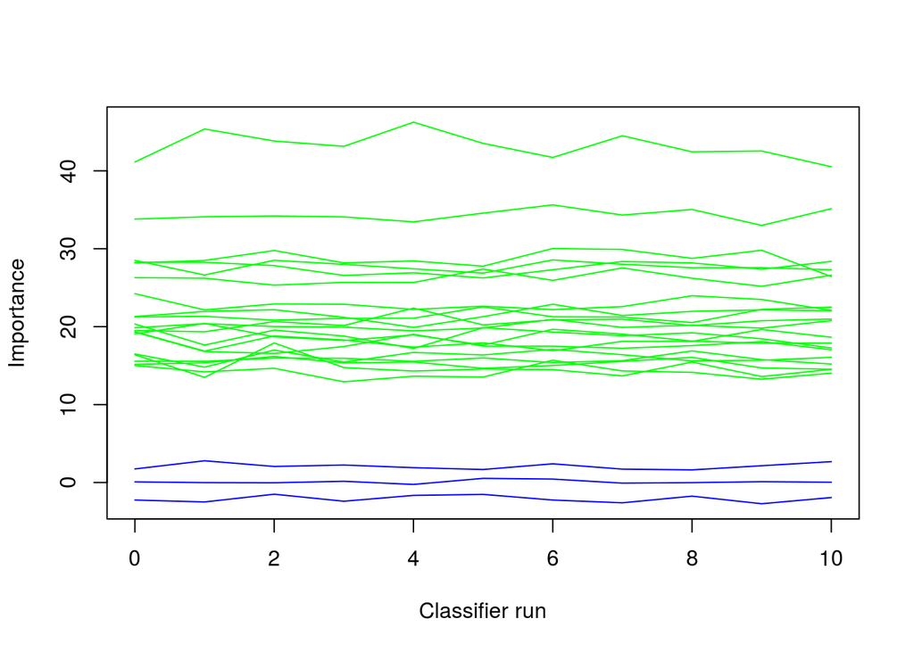

```r
plotImpHistory(boruta_output)
```

#### Conclusion for Boruta random forest test

**All features are important. None should be dropped.**

## EDA Conclusions For Transformed Data

It was determined earlier that three amino acids (C, F, I) from the single amino acid percent composition should be transformed by using the square root function. The square root transformation lowered the skewness from greater than 2 in all cases to {-0.102739 $\leq$ skew after transformation $\leq$ 0.3478132}.

| Amino Acid | Initial skewness | Skew after square root transform |
| --- | --- | --- |
| C, Cysteine | 2.538162 | 0.347813248 |
| F, Phenolalanine | 2.128118 | -0.102739748 |
| I, Isoleucine | 2.192145 | 0.293474879 |

The transformations of the three amino acids (C, F, I) did not appreciablly change any important measures such as the feature importance derived from the Boruta random forest feature selection work. Nor did the transformations of C,F,I apreciably change the correlation coeffiecient matrix, therefore the transformed data will be used throughout this experiment.

Regarding Boruta which is used for dimensionality reduction of Transformed data, it showed that all features (x variables) are important for the generation of a Decision Tree. My belief is that this would imply that given that Random Forest approach will be used it would wise to keep all features for that model test and throughout the generation of other models. All features have positive mean importance which are generated by a Gini calculation.

Regarding the coefficients of correlation of the Transformed dataset. There are no examples of coefficients which are greater than or equal to 0.75 therefore this implies that no features are collinear.

[^1]: “Applied Predictive Modeling”, Max Kuhn and Kjell Johnson, Springer Publishing, 2018, P.43